# Autoantibodies against type I IFNs in patients with life-threatening COVID-19 | Science

Research Article

# Autoantibodies against type I IFNs in patients with life-threatening COVID-19

1. [View ORCID Profile](https://orcid.org/0000-0002-5926-8437)Paul Bastard<sup>1</sup>,<sup>2</sup>,<sup>3</sup>,*,†,
2. [View ORCID Profile](https://orcid.org/0000-0001-5894-3878)Lindsey B. Rosen<sup>4</sup>,†,
3. [View ORCID Profile](https://orcid.org/0000-0002-9040-3289)Qian Zhang<sup>3</sup>,‡,
4. [View ORCID Profile](https://orcid.org/0000-0002-9907-4346)Eleftherios Michailidis<sup>5</sup>,‡,
5. [View ORCID Profile](https://orcid.org/0000-0003-0554-0244)Hans-Heinrich Hoffmann<sup>5</sup>,‡,
6. Yu Zhang<sup>4</sup>,‡,
7. [View ORCID Profile](https://orcid.org/0000-0001-9539-3203)Karim Dorgham<sup>6</sup>,‡,
8. Quentin Philippot<sup>1</sup>,<sup>2</sup>,‡,
9. Jérémie Rosain<sup>1</sup>,<sup>2</sup>,‡,
10. [View ORCID Profile](https://orcid.org/0000-0002-4020-824X)Vivien Béziat<sup>1</sup>,<sup>2</sup>,<sup>3</sup>,‡,
11. [View ORCID Profile](https://orcid.org/0000-0001-5998-2051)Jérémy Manry<sup>1</sup>,<sup>2</sup>,
12. [View ORCID Profile](https://orcid.org/0000-0001-9265-8026)Elana Shaw<sup>4</sup>,
13. [View ORCID Profile](https://orcid.org/0000-0001-7162-9808)Liis Haljasmägi<sup>7</sup>,
14. [View ORCID Profile](https://orcid.org/0000-0001-6755-791X)Pärt Peterson<sup>7</sup>,
15. [View ORCID Profile](https://orcid.org/0000-0001-6648-8684)Lazaro Lorenzo<sup>1</sup>,<sup>2</sup>,
16. [View ORCID Profile](https://orcid.org/0000-0001-9163-9122)Lucy Bizien<sup>1</sup>,<sup>2</sup>,
17. [View ORCID Profile](https://orcid.org/0000-0001-6439-4705)Sophie Trouillet-Assant<sup>8</sup>,<sup>9</sup>,
18. [View ORCID Profile](https://orcid.org/0000-0002-3432-3137)Kerry Dobbs<sup>4</sup>,
19. Adriana Almeida de Jesus<sup>4</sup>,
20. [View ORCID Profile](https://orcid.org/0000-0003-4902-5332)Alexandre Belot<sup>10</sup>,<sup>11</sup>,<sup>12</sup>,
21. [View ORCID Profile](https://orcid.org/0000-0002-7492-667X)Anne Kallaste<sup>13</sup>,
22. Emilie Catherinot<sup>14</sup>,
23. [View ORCID Profile](https://orcid.org/0000-0003-1123-4788)Yacine Tandjaoui-Lambiotte<sup>15</sup>,
24. [View ORCID Profile](https://orcid.org/0000-0001-7025-9526)Jeremie Le Pen<sup>5</sup>,
25. [View ORCID Profile](https://orcid.org/0000-0003-0146-9428)Gaspard Kerner<sup>1</sup>,<sup>2</sup>,
26. [View ORCID Profile](https://orcid.org/0000-0001-7291-5638)Benedetta Bigio<sup>3</sup>,
27. Yoann Seeleuthner<sup>1</sup>,<sup>2</sup>,
28. [View ORCID Profile](https://orcid.org/0000-0003-4427-2158)Rui Yang<sup>3</sup>,
29. [View ORCID Profile](https://orcid.org/0000-0001-7399-2766)Alexandre Bolze<sup>16</sup>,
30. [View ORCID Profile](https://orcid.org/0000-0001-5981-7259)András N. Spaan<sup>3</sup>,<sup>17</sup>,
31. Ottavia M. Delmonte<sup>4</sup>,
32. Michael S. Abers<sup>4</sup>,
33. [View ORCID Profile](https://orcid.org/0000-0002-5398-1717)Alessandro Aiuti<sup>18</sup>,
34. Giorgio Casari<sup>18</sup>,
35. [View ORCID Profile](https://orcid.org/0000-0001-5162-8445)Vito Lampasona<sup>18</sup>,
36. [View ORCID Profile](https://orcid.org/0000-0002-2172-2198)Lorenzo Piemonti<sup>18</sup>,
37. Fabio Ciceri<sup>18</sup>,
38. [View ORCID Profile](https://orcid.org/0000-0002-7313-7652)Kaya Bilguvar<sup>19</sup>,
39. Richard P. Lifton<sup>19</sup>,<sup>20</sup>,<sup>21</sup>,
40. Marc Vasse<sup>22</sup>,
41. David M. Smadja<sup>23</sup>,
42. [View ORCID Profile](https://orcid.org/0000-0003-3062-1214)Mélanie Migaud<sup>1</sup>,<sup>2</sup>,
43. [View ORCID Profile](https://orcid.org/0000-0002-2520-3272)Jérome Hadjadj<sup>24</sup>,
44. [View ORCID Profile](https://orcid.org/0000-0001-6612-7336)Benjamin Terrier<sup>25</sup>,
45. [View ORCID Profile](https://orcid.org/0000-0002-8875-2308)Darragh Duffy<sup>26</sup>,
46. [View ORCID Profile](https://orcid.org/0000-0003-2429-6320)Lluis Quintana-Murci<sup>27</sup>,<sup>28</sup>,
47. [View ORCID Profile](https://orcid.org/0000-0002-4571-044X)Diederik van de Beek<sup>29</sup>,
48. [View ORCID Profile](https://orcid.org/0000-0001-5355-702X)Lucie Roussel<sup>30</sup>,<sup>31</sup>,
49. [View ORCID Profile](https://orcid.org/0000-0003-1347-7767)Donald C. Vinh<sup>30</sup>,<sup>31</sup>,
50. [View ORCID Profile](https://orcid.org/0000-0002-5360-5180)Stuart G. Tangye<sup>32</sup>,<sup>33</sup>,
51. Filomeen Haerynck<sup>34</sup>,
52. [View ORCID Profile](https://orcid.org/0000-0003-1936-478X)David Dalmau<sup>35</sup>,
53. [View ORCID Profile](https://orcid.org/0000-0002-4916-2129)Javier Martinez-Picado<sup>36</sup>,<sup>37</sup>,<sup>38</sup>,
54. [View ORCID Profile](https://orcid.org/0000-0002-8103-0046)Petter Brodin<sup>39</sup>,<sup>40</sup>,
55. [View ORCID Profile](https://orcid.org/0000-0003-0592-8564)Michel C. Nussenzweig<sup>41</sup>,<sup>42</sup>,
56. [View ORCID Profile](https://orcid.org/0000-0002-7115-116X)Stéphanie Boisson-Dupuis<sup>1</sup>,<sup>2</sup>,<sup>3</sup>,
57. [View ORCID Profile](https://orcid.org/0000-0002-4344-8644)Carlos Rodríguez-Gallego<sup>43</sup>,<sup>44</sup>,
58. Guillaume Vogt<sup>45</sup>,
59. [View ORCID Profile](https://orcid.org/0000-0002-1853-9704)Trine H. Mogensen<sup>46</sup>,<sup>47</sup>,
60. [View ORCID Profile](https://orcid.org/0000-0002-6310-0434)Andrew J. Oler<sup>48</sup>,
61. Jingwen Gu<sup>48</sup>,
62. [View ORCID Profile](https://orcid.org/0000-0003-1717-048X)Peter D. Burbelo<sup>49</sup>,
63. [View ORCID Profile](https://orcid.org/0000-0003-0238-7176)Jeffrey I. Cohen<sup>50</sup>,
64. Andrea Biondi<sup>51</sup>,
65. [View ORCID Profile](https://orcid.org/0000-0002-0280-1704)Laura Rachele Bettini<sup>51</sup>,
66. Mariella D'Angio<sup>51</sup>,
67. [View ORCID Profile](https://orcid.org/0000-0001-7289-8823)Paolo Bonfanti<sup>52</sup>,
68. Patrick Rossignol<sup>53</sup>,
69. Julien Mayaux<sup>54</sup>,
70. [View ORCID Profile](https://orcid.org/0000-0001-7858-7866)Frédéric Rieux-Laucat<sup>24</sup>,
71. [View ORCID Profile](https://orcid.org/0000-0002-7886-2976)Eystein S. Husebye<sup>55</sup>,<sup>56</sup>,<sup>57</sup>,
72. Francesca Fusco<sup>58</sup>,
73. Matilde Valeria Ursini<sup>58</sup>,
74. Luisa Imberti<sup>59</sup>,
75. Alessandra Sottini<sup>59</sup>,
76. Simone Paghera<sup>59</sup>,
77. Eugenia Quiros-Roldan<sup>60</sup>,
78. Camillo Rossi<sup>61</sup>,
79. [View ORCID Profile](https://orcid.org/0000-0003-0029-9383)Riccardo Castagnoli<sup>62</sup>,
80. Daniela Montagna<sup>63</sup>,<sup>64</sup>,
81. [View ORCID Profile](https://orcid.org/0000-0002-1773-6482)Amelia Licari<sup>62</sup>,
82. Gian Luigi Marseglia<sup>62</sup>,
83. Xavier Duval<sup>65</sup>,<sup>66</sup>,<sup>67</sup>,<sup>68</sup>,<sup>69</sup>,
84. Jade Ghosn<sup>68</sup>,<sup>69</sup>,
85. HGID Lab§,
86. NIAID-USUHS Immune Response to COVID Group§,
87. COVID Clinicians§,
88. COVID-STORM Clinicians§,
89. Imagine COVID Group§,
90. French COVID Cohort Study Group§,
91. The Milieu Intérieur Consortium§,
92. CoV-Contact Cohort§,
93. Amsterdam UMC Covid-19 Biobank§,
94. COVID Human Genetic Effort§,
95. John S. Tsang<sup>70</sup>,<sup>71</sup>,
96. Raphaela Goldbach-Mansky<sup>4</sup>,
97. Kai Kisand<sup>7</sup>,
98. Michail S. Lionakis<sup>4</sup>,
99. Anne Puel<sup>1</sup>,<sup>2</sup>,<sup>3</sup>,
100. Shen-Ying Zhang<sup>1</sup>,<sup>2</sup>,<sup>3</sup>,
101. Steven M. Holland<sup>4</sup>,¶,
102. Guy Gorochov<sup>6</sup>,<sup>72</sup>,¶,
103. Emmanuelle Jouanguy<sup>1</sup>,<sup>2</sup>,<sup>3</sup>,¶,
104. Charles M. Rice<sup>5</sup>,¶,
105. Aurélie Cobat<sup>1</sup>,<sup>2</sup>,<sup>3</sup>,¶,
106. Luigi D. Notarangelo<sup>4</sup>,¶,
107. Laurent Abel<sup>1</sup>,<sup>2</sup>,<sup>3</sup>,¶,
108. Helen C. Su<sup>4</sup>,#,
109. Jean-Laurent Casanova<sup>1</sup>,<sup>2</sup>,<sup>3</sup>,<sup>42</sup>,<sup>73</sup>,*,#

Science 23 Oct 2020:  
Vol. 370, Issue 6515, eabd4585  
DOI: 10.1126/science.abd4585

## The genetics underlying severe COVID-19

The immune system is complex and involves many genes, including those that encode cytokines known as interferons (IFNs). Individuals that lack specific IFNs can be more susceptible to infectious diseases. Furthermore, the autoantibody system dampens IFN response to prevent damage from pathogen-induced inflammation. Two studies now examine the likelihood that genetics affects the risk of severe coronavirus disease 2019 (COVID-19) through components of this system (see the Perspective by Beck and Aksentijevich). Q. Zhang *et al.* used a candidate gene approach and identified patients with severe COVID-19 who have mutations in genes involved in the regulation of type I and III IFN immunity. They found enrichment of these genes in patients and conclude that genetics may determine the clinical course of the infection. Bastard *et al.* identified individuals with high titers of neutralizing autoantibodies against type I IFN-α2 and IFN-ω in about 10% of patients with severe COVID-19 pneumonia. These autoantibodies were not found either in infected people who were asymptomatic or had milder phenotype or in healthy individuals. Together, these studies identify a means by which individuals at highest risk of life-threatening COVID-19 can be identified.

*Science*, this issue p. [eabd4570](https://science.sciencemag.org/lookup/doi/10.1126/science.abd4570), p. [eabd4585](https://science.sciencemag.org/lookup/doi/10.1126/science.abd4585); see also p. [404](https://science.sciencemag.org/lookup/doi/10.1126/science.abe7591)

## Structured Abstract

### INTRODUCTION

Interindividual clinical variability is vast in humans infected with severe acute respiratory syndrome coronavirus 2 (SARS-CoV-2), ranging from silent infection to rapid death. Three risk factors for life-threatening coronavirus disease 2019 (COVID-19) pneumonia have been identified—being male, being elderly, or having other medical conditions—but these risk factors cannot explain why critical disease remains relatively rare in any given epidemiological group. Given the rising toll of the COVID-19 pandemic in terms of morbidity and mortality, understanding the causes and mechanisms of life-threatening COVID-19 is crucial.

### RATIONALE

B cell autoimmune infectious phenocopies of three inborn errors of cytokine immunity exist, in which neutralizing autoantibodies (auto-Abs) against interferon-γ (IFN-γ) (mycobacterial disease), interleukin-6 (IL-6) (staphylococcal disease), and IL-17A and IL-17F (mucocutaneous candidiasis) mimic the clinical phenotypes of germline mutations of the genes that encode the corresponding cytokines or receptors. Human inborn errors of type I IFNs underlie severe viral respiratory diseases. Neutralizing auto-Abs against type I IFNs, which have been found in patients with a few underlying noninfectious conditions, have not been unequivocally shown to underlie severe viral infections. While searching for inborn errors of type I IFN immunity in patients with life-threatening COVID-19 pneumonia, we also tested the hypothesis that neutralizing auto-Abs against type I IFNs may underlie critical COVID-19. We searched for auto-Abs against type I IFNs in 987 patients hospitalized for life-threatening COVID-19 pneumonia, 663 asymptomatic or mildly affected individuals infected with SARS-CoV-2, and 1227 healthy controls from whom samples were collected before the COVID-19 pandemic.

### RESULTS

At least 101 of 987 patients (10.2%) with life-threatening COVID-19 pneumonia had neutralizing immunoglobulin G (IgG) auto-Abs against IFN-ω (13 patients), against the 13 types of IFN-α (36), or against both (52) at the onset of critical disease; a few also had auto-Abs against the other three individual type I IFNs. These auto-Abs neutralize high concentrations of the corresponding type I IFNs, including their ability to block SARS-CoV-2 infection in vitro. Moreover, all of the patients tested had low or undetectable serum IFN-α levels during acute disease. These auto-Abs were present before infection in the patients tested and were absent from 663 individuals with asymptomatic or mild SARS-CoV-2 infection (*P* < 10<sup>−16</sup>). They were present in only 4 of 1227 (0.33%) healthy individuals (*P* < 10<sup>−16</sup>) before the pandemic. The patients with auto-Abs were 25 to 87 years old (half were over 65) and of various ancestries. Notably, 95 of the 101 patients with auto-Abs were men (94%).

### CONCLUSION

A B cell autoimmune phenocopy of inborn errors of type I IFN immunity accounts for life-threatening COVID-19 pneumonia in at least 2.6% of women and 12.5% of men. In these patients, adaptive autoimmunity impairs innate and intrinsic antiviral immunity. These findings provide a first explanation for the excess of men among patients with life-threatening COVID-19 and the increase in risk with age. They also provide a means of identifying individuals at risk of developing life-threatening COVID-19 and ensuring their enrolment in vaccine trials. Finally, they pave the way for prevention and treatment, including plasmapheresis, plasmablast depletion, and recombinant type I IFNs not targeted by the auto-Abs (e.g., IFN-β).

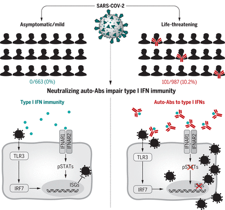

Neutralizing auto-Abs to type I IFNs underlie life-threatening COVID-19 pneumonia.

We tested the hypothesis that neutralizing auto-Abs against type I IFNs may underlie critical COVID-19 by impairing the binding of type I IFNs to their receptor and the activation of the downstream responsive pathway. Neutralizing auto-Abs are represented in red, and type I IFNs are represented in blue. In these patients, adaptive autoimmunity impairs innate and intrinsic antiviral immunity. ISGs, IFN-stimulated genes; TLR, Toll-like receptor; IFNAR, IFN-α/β receptor; pSTAT, phosphorylated signal transducers and activators of transcription; IRF, interferon regulatory factor.

## Abstract

Interindividual clinical variability in the course of severe acute respiratory syndrome coronavirus 2 (SARS-CoV-2) infection is vast. We report that at least 101 of 987 patients with life-threatening coronavirus disease 2019 (COVID-19) pneumonia had neutralizing immunoglobulin G (IgG) autoantibodies (auto-Abs) against interferon-ω (IFN-ω) (13 patients), against the 13 types of IFN-α (36), or against both (52) at the onset of critical disease; a few also had auto-Abs against the other three type I IFNs. The auto-Abs neutralize the ability of the corresponding type I IFNs to block SARS-CoV-2 infection in vitro. These auto-Abs were not found in 663 individuals with asymptomatic or mild SARS-CoV-2 infection and were present in only 4 of 1227 healthy individuals. Patients with auto-Abs were aged 25 to 87 years and 95 of the 101 were men. A B cell autoimmune phenocopy of inborn errors of type I IFN immunity accounts for life-threatening COVID-19 pneumonia in at least 2.6% of women and 12.5% of men.

https://creativecommons.org/licenses/by/4.0/

This is an open-access article distributed under the terms of the [Creative Commons Attribution license](https://creativecommons.org/licenses/by/4.0/), which permits unrestricted use, distribution, and reproduction in any medium, provided the original work is properly cited.

[View Full Text](https://science.sciencemag.org/content/370/6515/eabd4585.full)

   David B. Beck et al., Science, 2020
2. [The genetics underlying severe COVID-19](https://science.sciencemag.org/content/370/6515/418.14?rss=1&intcmp=trendmd-sci)

   Laura M. Zahn et al., Science, 2020
3. [Inborn errors of type I IFN immunity in patients with life-threatening COVID-19](https://science.sciencemag.org/content/early/2020/09/23/science.abd4570.abstract?intcmp=trendmd-sci)

   Qian Zhang et al., Science
4. [Systems biological assessment of immunity to mild versus severe COVID-19 infection in humans](https://science.sciencemag.org/content/early/2020/08/10/science.abc6261?intcmp=trendmd-sci)

   Prabhu S. Arunachalam et al., Science
5. [HiJAKing SARS-CoV-2? The potential role of JAK inhibitors in the management of COVID-19](https://immunology.sciencemag.org/content/5/47/eabc5367?intcmp=trendmd-imm)

   Liu Daisy Liu et al., Journal of Molecular Cell Biology
3. [Adaptive immune responses to SARS-CoV-2 infection in severe versus mild individuals](https://www.nature.com/articles/s41392-020-00263-y?utm_source=TrendMD&utm_medium=cpc&utm_campaign=Signal_Transduction_and_Targeted_Therapy_TrendMD_1)

   Healio

### [Science](https://science.sciencemag.org/content/370/6515)

Vol 370, Issue 6515  
23 October 2020

### Related Content

- Research Article

### [Inborn errors of type I IFN immunity in patients with life-threatening COVID-19](https://science.sciencemag.org/content/370/6515/eabd4570)

- Perspective

### [Susceptibility to severe COVID-19](https://science.sciencemag.org/content/370/6515/404)

- Research Articles

### [A comparison of four serological assays for detecting anti–SARS-CoV-2 antibodies in human serum samples from different populations](http://stm.sciencemag.org/content/12/559/eabc3103)

- Research Articles

### [Immune responses to SARS-CoV-2 infection in hospitalized pediatric and adult patients](http://stm.sciencemag.org/content/12/564/eabd5487)

- Reports

### [Antibody signature induced by SARS-CoV-2 spike protein immunogens in rabbits](http://stm.sciencemag.org/content/12/550/eabc3539)

- Research Articles

### [An *Alphavirus*-derived replicon RNA vaccine induces SARS-CoV-2 neutralizing antibody and T cell responses in mice and nonhuman primates](http://stm.sciencemag.org/content/12/555/eabc9396)

### Similar Articles in:

- [PubMed](https://science.sciencemag.org/lookup/external-ref?link_type=MED_NBRS&access_num=32972996)
- Google Scholar

## Cited By...

### 15 January 2021

Vol 371, Issue 6526

[figure not shown]

[Table of Contents](http://science.sciencemag.org/content/371/6526)

### Climate Science

- [Fighting the good fight](https://science.sciencemag.org/content/371/6526/242)

### SCI COMMUN

- [News at a glance](https://science.sciencemag.org/content/371/6526/216)

### Coronavirus

- [Herd immunity by infection is not an option](https://science.sciencemag.org/content/371/6526/230)

### Working Life

- [No use in shouting](https://science.sciencemag.org/content/371/6526/314)

## Get Our E-Alerts

Science Table of Contents

Science Daily News

Weekly News Roundup

Science Editor's Choice

First Release Notification

Science Careers Job Seeker

Country

Email

Sign up today

Required fields are indicated by an asterisk (*)